# COVID 19 Hospitalization Burden and Hospital Strain Across US States

Author

Tasmiah Khan

```r
library(conflicted)
library(tidyverse)
library(janitor)
library(lubridate)
library(knitr)
library(maps)

study_start <- ymd("2020-09-01")
study_end   <- ymd("2021-03-07")
```

# Introduction

The fall and winter COVID-19 surge of 2020-2021 produced a major increase in hospitalizations across the United States. Hospitalization counts alone, however, do not tell the full story. Examining whether a states experienced an unusually high hospitalization burden relative to its population or whether its hospitals had sufficient resources to absorb that burden provides a more complete picture of the surge. States with similar COVID-19 hospitalization did not necessarily experience the same degree of hospital strain because they differed in population characteristics, staffed bed capacity, existing occupancy, and staffing conditions.

The primary study period is September 1, 2020 through March 7, 2021, the final date on which the COVID Tracking Project collected data.

## Research question

**Across all 50 US states, how were pre-pandemic state demographic characteristics and September 2020 hospital conditions associated with peak COVID-19 hospitalization burden and hospital-system strain during the fall and winter 2020-2021 surge?**

My midterm analysis will look at four different data sources in an attempt to answer this question:

1. daily state COVID-19 measures from the primary dataset, the COVID Tracking Project
2. daily state hospital-utilization measures from the US Department of Health and Human Services (HHS)
3. pre pandemic demographic estimates from the 2019 American Community Survey (ACS), an annual program run by the US Census Bureau
4. the US Census Bureau’s 2020 Population Density Data

This analysis addresses three objectives:

1. describe differences in the timing and magnitude of peak COVID-19 hospitalization rates across the 50 states.
2. examine whether pre pandemic older age, poverty, health-insurance coverage, and population density were associated with peak COVID-19 hospitalization burden (defined by current hospitalization rates per 100,00 residents).
3. examine whether September 2020 staffed inpatient and adult ICU bed availability/occupancy, and critical staffing shortages were associated with measures of peak hospital strain from October 2020 through March 7, 2021

## Hypothesis

I hypothesized that the states with higher poverty rates, uninsured rates, older-adult population percents, and population-density would generally experience higher peak COVID-19 hospitalization rates. I also hypothesized that states with fewer staffed inpatient and adult ICU hospital beds (per 100,000 residents), higher September occupancy, and more critical staffing shortages in September would experience a greater hospital strain (defined by peak inpatient or adult ICU occupancy and staffing shortages in the later surge period).

# Data Preparation

A total of 6 datasets were downloaded from publicly available government and archival historical data websites. Daily COVID-19 hospitalization data was derived from the **COVID Tracking Project** website. Hospital capacity data came from the **HHS COVID-19 Reported Patient Impact and Hospital Capacity by State Timeseries** dataset. HHS warns that data are aggregated from facility reports, reporting coverage varies (may be incomplete), and no statistical adjustment is applied for nonresponse/missingness. State demographic characteristics were obtained from the **2019 ACS one-year subject tables** available through the US Census Bureau. Tables S0101 provided age information, S1701 provided poverty status in the past 12 months information, and S2701 provided selected characteristics of health insurance coverage in the US information. State population and population density were obtained from the **Census Bureau’s 2020 Population Density Data Table** from their website.

The **COVID Tracking Project** and **HHS** data were both restricted to the 50 states and the study period from September 1, 2020, through March 7, 2021 (when COVID Tracking Project officially ended all data collection). The US territories were excluded to keep a consistent state-level analysis. While importing the **COVID Tracking Project** import, I faced a parsing problems. I removed the two unused antibody-testing variables during import because they were being interpreted as logical variables and were unrelated to the research question. **Current COVID-19 hospitalizations** were retained as the *primary measure* of hospitalization burden. The HHS file also had parsing problems because some of the numeric values contained commas, so I imported them as character variables and some were later converted into numeric form.

The **2019 ACS estimates** data represents state characteristics immediately before the pandemic in order to improve the temporal flow and order of the analysis because this would help ensure that I am treating state characteristics as potential explanatory state characteristics of hospital burden. For the age table (S0101), the percentage of residents age 65 or older was selected from the Selected Age Categories to represent the relative size of each state’s older population. For the poverty table (S1701), the percentage below the poverty level was selected for the population whose poverty status was determined to represent the prevalence of poverty. For the insurance table (S2701), the percentage uninsured was selected from the civilian noninstitutionalized population to represent gaps in coverage. These estimates can provide state level measures that directly relate to characteristics in my question. The count and margin of error columns were excluded. Each table was turned into long format from state columns to state rows. The estimate descriptions were removed from the state names, percent signs were removed, and the percents were converted to numeric. The resulting age, poverty, and insurance datasets each contained one observation per state and were joined by state name.

The population density dataset that I had downloaded included historical data from 1910 through 2020, and observations for regions, the national total, and US territories. I restricted the dataset to the year 2020 and the 50 states. Comma separations were removed from the resident population and population-density values before they were converted to numeric form. The cleaned density data were joined with the combined ACS data by state name, producing a dataset containing the percentage of older population, percentage below poverty, percentage uninsured, 2020 resident population, and population density for each state.

Before combining all the sources, the **COVID Tracking Project** and **HHS** were checked for duplicate state-date observations, and the state-characteristics dataset was checked for duplicate states. No repeated observations were identified. The **COVID Tracking Project** was used as the primary dataset. **HHS** records were added by matching state and date, and the population variables were added by matching state. After the joins, the number of rows was compared with the original cleaned COVID dataset. The joins did not have duplicate observations.

Several variables were created after the datasets were merged. Current COVID-19 hospitalizations, staffed inpatient beds, and staffed adult ICU beds were expressed per 100,000 residents using the 2020 Census population. Inpatient and adult ICU occupancy were calculated as percentages from HHS utilization proportions. The percentage of all occupied inpatient beds occupied by confirmed adult COVID-19 patients was also calculated. The staffing shortage percent was calculated as the number of hospitals reporting a critical staffing shortage divided by the number reporting either a shortage or no shortage.

Note: The two Census years from the 2019 ACS estiamtes and 2020 Census population serve different purposes. The 2019 ACS measures age, poverty, and insurance before COVID-19 hospitalization outcomes, whereas the 2020 Census Population Density table provides a denomintor for per-capita measures. The density estimate is closest to this study period of 2020-2021. Although deaths, births, and migration did change state populations, these changes were not measured daily, and this analysis purpose was to compare broad differences in density across states rather than small short-term changes within states. Population density, for the purpose of this analysis, will be treated as relatively stable state character and not as a measure changing during the surge.

## Data sources

```r
# Dataset 1: COVID Tracking Project
covid_raw <- read_csv(
  "covid_tracking.csv",col_select = -c(
    negativeTestsPeopleAntibody,
    positiveTestsPeopleAntibody
  ),
  show_col_types = FALSE
)
```

```r
# Dataset 2: HHS hospital-capacity time series
hhs_raw <- read_csv(
  "hhs_data.csv",
  col_types = cols(.default = col_character())
)
```

```r
# Dataset 3a: 2019 ACS age data
age_raw <- read_csv(
  "acs_age_sex.csv",
  show_col_types = FALSE
)
```

```r
# Dataset 3b: 2019 ACS poverty data
poverty_raw <- read_csv(
  "acs_poverty.csv",
  show_col_types = FALSE
)
```

```r
# Dataset 3c: 2019 ACS insurance data
insurance_raw <- read_csv(
  "acs_insurance.csv",
  show_col_types = FALSE
)
```

```r
# Dataset 4: 2020 Census population-density table
density_raw <- read_csv(
  "population_density2020.csv",
  show_col_types = FALSE
)
```

## Clean the COVID Tracking Project data

```r
covid <- covid_raw |>
  mutate(
    date = as.Date(date),
    hospitalized_currently =
      as.numeric(hospitalizedCurrently)
  ) |>
  dplyr::filter(
    state %in% state.abb,
    date >= study_start,
    date <= study_end
  ) |>
  dplyr::select(
    state,
    date,
    hospitalized_currently
  )
```

## Clean the HHS data

```r
hhs <- hhs_raw |>

  mutate(
    date = as.Date(date),

    # Convert selected hospital variables from character to numeric.
    # parse_number for handling comma-formatted values
    across(
      c(
        inpatient_beds,
        inpatient_beds_coverage,
        inpatient_beds_used,
        inpatient_beds_used_coverage,
        inpatient_beds_utilization,
        adult_icu_bed_utilization,
        total_staffed_adult_icu_beds,
        total_staffed_adult_icu_beds_coverage,
        staffed_adult_icu_bed_occupancy,
        staffed_adult_icu_bed_occupancy_coverage,
        total_adult_patients_hospitalized_confirmed_covid,
        total_adult_patients_hospitalized_confirmed_covid_coverage,
        staffed_icu_adult_patients_confirmed_covid,
        staffed_icu_adult_patients_confirmed_covid_coverage,
        critical_staffing_shortage_today_yes,
        critical_staffing_shortage_today_no,
        critical_staffing_shortage_today_not_reported
      ),
      parse_number
    )
  ) |>


  dplyr::filter(
    state %in% state.abb,
    date >= study_start,
    date <= study_end
  ) |>

  # Keep the hospital measures needed
  select(
    state,
    date,
    inpatient_beds,
    inpatient_beds_coverage,
    inpatient_beds_used,
    inpatient_beds_used_coverage,
    inpatient_beds_utilization,
    adult_icu_bed_utilization,
    total_staffed_adult_icu_beds,
    total_staffed_adult_icu_beds_coverage,
    staffed_adult_icu_bed_occupancy,
    staffed_adult_icu_bed_occupancy_coverage,
    total_adult_patients_hospitalized_confirmed_covid,
    total_adult_patients_hospitalized_confirmed_covid_coverage,
    staffed_icu_adult_patients_confirmed_covid,
    staffed_icu_adult_patients_confirmed_covid_coverage,
    critical_staffing_shortage_today_yes,
    critical_staffing_shortage_today_no,
    critical_staffing_shortage_today_not_reported
  )
```

## Clean the ACS health insurance data

```r
insurance <- insurance_raw |>
  slice(1) |>
  dplyr::select(
    ends_with("!!Percent Uninsured!!Estimate")
  ) |>
  pivot_longer(
    cols = everything(),
    names_to = "state_name",
    values_to = "uninsured_pct"
  ) |>
  mutate(
    state_name = sub(
      "!!Percent Uninsured!!Estimate",
      "",
      state_name
    ),
    uninsured_pct = as.numeric(
      sub("%", "", uninsured_pct)
    )
  ) |>
  dplyr::filter(
    state_name %in% state.name
  )
```

## Clean the ACS age data

```r
# age_raw |>
 # dplyr::select(`Label (Grouping)`) |>
 # print(n = Inf)

age <- age_raw |>

  # Select the "65 years and over" row
  slice(32) |>

  # Select the overall percentage estimate for each state
  dplyr::select(
    ends_with("!!Percent!!Estimate")
  ) |>

  # Change state columns into state rows
  pivot_longer(
    cols = everything(),
    names_to = "state_name",
    values_to = "age65_pct"
  ) |>

  # Clean state names and convert percentages to numeric
  mutate(
    state_name = sub(
      "!!Percent!!Estimate",
      "",
      state_name
    ),
    age65_pct = as.numeric(
      sub("%", "", age65_pct)
    )
  ) |>

  # Keep the 50 states
  dplyr::filter(
    state_name %in% state.name
  )
```

## Clean the ACS poverty data

```r
poverty <- poverty_raw |>
   dplyr::filter(`Label (Grouping)` ==
      "Population for whom poverty status is determined"
  ) |>

  # Percent below poverty for each state
  select(
    ends_with(
      "!!Percent below poverty level!!Estimate"
    )
  ) |>

  # Change state columns into rows
  pivot_longer(
    cols = everything(),
    names_to = "state_name",
    values_to = "poverty_pct"
  ) |>

  # Remove description from the state names and convert percentages
  mutate(
    state_name = sub(
      "!!Percent below poverty level!!Estimate$",
      "",
      state_name
    ),
    poverty_pct = as.numeric(
    sub("%", "", poverty_pct)
  )
  ) |>

  # Keep the 50 states
  dplyr::filter(
    state_name %in% state.name
  )
```

## Merge ACS demographic datasets

```r
acs <- age |>

  # Add poverty percent by state
  left_join(
    poverty,
    by = "state_name"
  ) |>

  # Add uninsured percent by state
  left_join(
    insurance,
    by = "state_name"
  ) |>

  # Add the state abbreviation
  mutate(
    state = state.abb[
      match(state_name, state.name)
    ]
  ) |>

  # Arrange the variables
  select(
    state,
    state_name,
    age65_pct,
    poverty_pct,
    uninsured_pct
  )
```

## Cleaning 2020 population density data

```r
density <- density_raw |>

  # Keep 2020 and the 50 states
  dplyr::filter(
    Year == 2020,
    Name %in% state.name
  ) |>

  # Create variables
  mutate(
    population_2020 = as.numeric(
      gsub(",", "", `Resident Population`)
    ),
    population_density = as.numeric(
      gsub(",", "", `Resident Population Density`)
    )
  ) |>

  # Rename the state-name variable
  rename(
    state_name = Name
  ) |>

  # Keep only the variables needed for the merge
  dplyr::select(
    state_name,
    population_2020,
    population_density
  )
```

## Merge ACS demographics and population density

```r
state_characteristics <- acs |>
  left_join(
    density,
    by = "state_name"
  )
```

## duplicate rows checking

```r
 covid_duplicates <- covid |>
  count(state, date) |>
  dplyr::filter(n > 1)

hhs_duplicates <- hhs |>
  count(state, date) |>
  dplyr::filter(n > 1)

state_duplicates <- state_characteristics |>
  count(state) |>
  dplyr::filter(n > 1)
duplicate_check <- tibble(
  dataset = c(
    "COVID Tracking Project",
    "HHS Hospital Capacity",
    "State characteristics"
  ),
  repeated_observations = c(
    nrow(covid_duplicates),
    nrow(hhs_duplicates),
    nrow(state_duplicates)
  )
)

kable(
  duplicate_check,
  caption = "Repeated observations before combining datasets"
)
```

Repeated observations before combining datasets

| dataset | repeated_observations |
| --- | --- |
| COVID Tracking Project | 0 |
| HHS Hospital Capacity | 0 |
| State characteristics | 0 |

## Merge all datasets and state characteristics

```r
analysis_daily <- covid |>
  left_join(
    hhs,
    by = c("state", "date")
  ) |>
  left_join(
    state_characteristics,
    by = "state"
  )

combined_duplicates <- analysis_daily |>
  count(state, date) |>
  dplyr::filter(n > 1)

merge_check <- tibble(
  check = c(
    "COVID rows before combining",
    "Rows after combining",
    "Additional rows",
    "Repeated date observations"
  ),
  result = c(
    nrow(covid),
    nrow(analysis_daily),
    nrow(analysis_daily) - nrow(covid),
    nrow(combined_duplicates)
  )
)

kable(
  merge_check,
  caption = "Checks performed after combining the datasets"
)
```

Checks performed after combining the datasets

| check | result |
| --- | --- |
| COVID rows before combining | 9400 |
| Rows after combining | 9400 |
| Additional rows | 0 |
| Repeated date observations | 0 |

## Create important variables

```r
  analysis_daily <- analysis_daily |>
  mutate(
    hosp_rate =
      hospitalized_currently / population_2020 * 100000,

    beds_per_100k =
      inpatient_beds / population_2020 * 100000,

    icu_beds_per_100k =
      total_staffed_adult_icu_beds /
      population_2020 * 100000,

    inpatient_occupancy_pct =
      inpatient_beds_utilization * 100,

    icu_occupancy_pct =
      adult_icu_bed_utilization * 100,

    confirmed_adult_covid_share_pct =
      total_adult_patients_hospitalized_confirmed_covid /
      inpatient_beds_used * 100,

    staffing_shortage_pct =
      critical_staffing_shortage_today_yes /
      (
        critical_staffing_shortage_today_yes +
        critical_staffing_shortage_today_no
      ) * 100
  )
```

## Check for implausible values

```r
expectation_checks <- tibble(
  Check = c(
    "Negative current hospitalizations",
    "Negative hospitalization rates",
    "Inpatient occupancy below 0%",
    "Inpatient occupancy above 100%",
    "ICU occupancy below 0%",
    "ICU occupancy above 100%",
    "COVID inpatient share below 0%",
    "COVID inpatient share above 100%",
    "Staffing-shortage percentage below 0%",
    "Staffing-shortage percentage above 100%",
    "Dates before the study period",
    "Dates after the study period"
  ),

  Number = c(
    sum(
      analysis_daily$hospitalized_currently < 0,
      na.rm = TRUE
    ),
    sum(
      analysis_daily$hosp_rate < 0,
      na.rm = TRUE
    ),
    sum(
      analysis_daily$inpatient_occupancy_pct < 0,
      na.rm = TRUE
    ),
    sum(
      analysis_daily$inpatient_occupancy_pct > 100,
      na.rm = TRUE
    ),
    sum(
      analysis_daily$icu_occupancy_pct < 0,
      na.rm = TRUE
    ),
    sum(
      analysis_daily$icu_occupancy_pct > 100,
      na.rm = TRUE
    ),
    sum(
      analysis_daily$confirmed_adult_covid_share_pct < 0,
      na.rm = TRUE
    ),
    sum(
      analysis_daily$confirmed_adult_covid_share_pct > 100,
      na.rm = TRUE
    ),
    sum(
      analysis_daily$staffing_shortage_pct < 0,
      na.rm = TRUE
    ),
    sum(
      analysis_daily$staffing_shortage_pct > 100,
      na.rm = TRUE
    ),
    sum(
      analysis_daily$date < study_start,
      na.rm = TRUE
    ),
    sum(
      analysis_daily$date > study_end,
      na.rm = TRUE
    )
  )
)

kable(
  expectation_checks,
  caption = "Checks for implausible values"
)
```

Checks for implausible values

| Check | Number |
| --- | --- |
| Negative current hospitalizations | 0 |
| Negative hospitalization rates | 0 |
| Inpatient occupancy below 0% | 0 |
| Inpatient occupancy above 100% | 31 |
| ICU occupancy below 0% | 0 |
| ICU occupancy above 100% | 6 |
| COVID inpatient share below 0% | 0 |
| COVID inpatient share above 100% | 0 |
| Staffing-shortage percentage below 0% | 0 |
| Staffing-shortage percentage above 100% | 0 |
| Dates before the study period | 0 |
| Dates after the study period | 0 |

Variables were checked for values outside their expected ranges before the weekly and state-level datasets were created. No negative hospitalization or occupancy values were identified, and all dates fell within the study period. Inpatient occupancy exceeded 100% on 31 state-days, while adult ICU occupancy exceeded 100% on six state-days. Because these values could represent severe strain, reporting inconsistencies, or data errors, the affected states and dates were examined further.

```r
inpatient_above_100 <- analysis_daily |>
  dplyr::filter(inpatient_occupancy_pct > 100) |>
  dplyr::select(
    state,
    state_name,
    date,
    inpatient_occupancy_pct
  ) |>
  arrange(desc(inpatient_occupancy_pct))

kable(
  inpatient_above_100,
  digits = 1,
  caption = "Inpatient occupancy above 100%"
)
```

Inpatient occupancy above 100%

| state | state_name | date | inpatient_occupancy_pct |
| --- | --- | --- | --- |
| RI | Rhode Island | 2020-09-02 | 118.0 |
| RI | Rhode Island | 2020-09-11 | 117.6 |
| RI | Rhode Island | 2020-09-01 | 117.3 |
| RI | Rhode Island | 2020-10-06 | 115.7 |
| RI | Rhode Island | 2020-10-01 | 115.5 |
| RI | Rhode Island | 2020-09-03 | 106.2 |
| RI | Rhode Island | 2020-10-03 | 104.3 |
| RI | Rhode Island | 2020-09-04 | 103.7 |
| RI | Rhode Island | 2021-01-30 | 103.5 |
| RI | Rhode Island | 2020-09-15 | 102.8 |
| RI | Rhode Island | 2021-02-18 | 102.7 |
| RI | Rhode Island | 2021-01-26 | 102.5 |
| RI | Rhode Island | 2020-09-05 | 102.3 |
| RI | Rhode Island | 2021-01-20 | 102.3 |
| RI | Rhode Island | 2021-02-12 | 102.2 |
| RI | Rhode Island | 2021-02-03 | 102.2 |
| RI | Rhode Island | 2021-01-29 | 102.0 |
| RI | Rhode Island | 2021-02-10 | 102.0 |
| RI | Rhode Island | 2021-01-22 | 101.8 |
| RI | Rhode Island | 2020-09-14 | 101.8 |
| RI | Rhode Island | 2021-01-21 | 101.7 |
| RI | Rhode Island | 2021-01-27 | 101.5 |
| RI | Rhode Island | 2021-02-17 | 101.4 |
| RI | Rhode Island | 2021-01-28 | 101.4 |
| RI | Rhode Island | 2021-02-04 | 101.1 |
| RI | Rhode Island | 2021-02-02 | 101.1 |
| RI | Rhode Island | 2020-09-12 | 101.1 |
| RI | Rhode Island | 2021-02-09 | 101.0 |
| RI | Rhode Island | 2021-02-06 | 100.7 |
| RI | Rhode Island | 2021-01-25 | 100.5 |
| RI | Rhode Island | 2021-01-19 | 100.2 |

```r
icu_above_100 <- analysis_daily |>
  dplyr::filter(icu_occupancy_pct > 100) |>
  dplyr::select(
    state,
    state_name,
    date,
    icu_occupancy_pct
  ) |>
  arrange(desc(icu_occupancy_pct))

kable(
  icu_above_100,
  digits = 1,
  caption = "Adult ICU occupancy above 100%"
)
```

Adult ICU occupancy above 100%

| state | state_name | date | icu_occupancy_pct |
| --- | --- | --- | --- |
| IA | Iowa | 2020-09-03 | 221.6 |
| NM | New Mexico | 2020-12-01 | 102.4 |
| NM | New Mexico | 2020-12-06 | 101.4 |
| NM | New Mexico | 2020-11-30 | 101.2 |
| NM | New Mexico | 2020-12-25 | 100.2 |
| NM | New Mexico | 2020-12-02 | 100.2 |

```r
analysis_daily |>
  dplyr::filter(inpatient_occupancy_pct > 100) |>
  count(state, state_name, name = "Number_above_100") |>
  arrange(desc(Number_above_100)) |>
  kable(
    caption = "Inpatient occupancy values above 100% by state")
```

Inpatient occupancy values above 100% by state

| state | state_name | Number_above_100 |
| --- | --- | --- |
| RI | Rhode Island | 31 |

```r
analysis_daily |>
  dplyr::filter(icu_occupancy_pct > 100) |>
  count(state, state_name, name = "Number_above_100") |>
  arrange(desc(Number_above_100)) |>
  kable(
    caption = "ICU occupancy values above 100% by state"
  )
```

ICU occupancy values above 100% by state

| state | state_name | Number_above_100 |
| --- | --- | --- |
| NM | New Mexico | 5 |
| IA | Iowa | 1 |

All 31 inpatient occupancy observations exceeding 100% occurred in Rhode Island and ranged from 100.2% to 118.0%. These observations appeared on multiple dates, particularly near the beginning of September and again during January and February 2021. Because the elevated values formed a repeated pattern rather than a single isolated observation, they were retained as possible indications that reported inpatient use exceeded reported staffed capacity. They were interpreted cautiously because differences in reporting or capacity definitions could also have contributed to values above 100%.

Adult ICU occupancy exceeded 100% on five observations occurred in New Mexico between November 30 and December 25, 2020, and ranged from 100.2% to 102.4%. These values were retained because they occurred during a concentrated period of the winter surge and could indicate that ICU use slightly exceeded reported staffed capacity. The remaining observation was an ICU occupancy of 221.6% in Iowa on September 3, 2020. Because this value was substantially larger than every other observation, it was examined separately.

```r
analysis_daily |>
  dplyr::filter(
    state == "IA",
    date >= as.Date("2020-09-01"),
    date <= as.Date("2020-09-07")
  ) |>
  dplyr::select(
    state,
    date,
    icu_occupancy_pct
  ) |>
  arrange(date) |>
  kable(
    caption = "Iowa ICU occupancy surrounding September 3, 2020"
  )
```

Iowa ICU occupancy surrounding September 3, 2020

| state | date | icu_occupancy_pct |
| --- | --- | --- |
| IA | 2020-09-01 | 65.15152 |
| IA | 2020-09-02 | 65.45961 |
| IA | 2020-09-03 | 221.58774 |
| IA | 2020-09-04 | 65.54622 |
| IA | 2020-09-05 | 65.12605 |
| IA | 2020-09-06 | 60.25281 |
| IA | 2020-09-07 | 59.47075 |

Iowa’s adult ICU occupancy remained between approximately 59% and 66% on the surrounding days, while the September 3 value was 221.6%. The absence of a gradual increase or decline suggested that this was an isolated reporting inconsistency. The September 3 Iowa ICU occupancy value was recoded as missing rather than removing the entire state-day observation. This preserved the other valid measurements reported for Iowa on that date.

## Correct the Iowa ICU value

```r
# correct Iowa ICU value
analysis_daily <- analysis_daily |>
  mutate(
    icu_occupancy_pct = if_else(
      state == "IA" &
        date == as.Date("2020-09-03") &
        icu_occupancy_pct > 200,
      NA_real_,
      icu_occupancy_pct
    )
  )

iowa_check <- analysis_daily |>
  dplyr::filter(
    state == "IA",
    date == as.Date("2020-09-03")
  ) |>
  dplyr::select(
    state,
    state_name,
    date,
    icu_occupancy_pct
  )

kable(
  iowa_check,
  caption = "Corrected Iowa daily ICU occupancy"
)
```

Corrected Iowa daily ICU occupancy

| state | state_name | date | icu_occupancy_pct |
| --- | --- | --- | --- |
| IA | Iowa | 2020-09-03 | NA |

## Create weekly and state-summary datasets

Daily hospital reports can fluctuate because of reporting delays and later corrections. Weekly averages were therefore calculated to reduce the influence of individual daily fluctuations. The weekly data were then used to identify the timing and magnitude of peak hospitalization burden and hospital occupancy for each state.

Three analytical datasets were prepared for different purposes.

1. analysis_daily contains one observation for each state and date and is used to examine daily hospital measures, investigate implausible values, and calculate September hospital conditions.
2. analysis_weekly contains state-level weekly averages of hospitalization, inpatient occupancy, ICU occupancy, and staffing shortages.
3. state_summary contains one observation per state and combines peak hospitalization and occupancy during the full study period with demographic characteristics and population density. A separate state_analysis dataset is created below to compare September hospital conditions with peak hospital strain from October 2020 through March 7, 2021.

```r
# create weekly averages
analysis_weekly <- analysis_daily |>
  mutate(
    study_week = ceiling(
      (as.numeric(date - study_start) + 1) / 7
    )
  ) |>
  group_by(
    state,
    state_name,
    study_week
  ) |>
  summarise(
    hosp_rate =
      mean(hosp_rate, na.rm = TRUE),

    inpatient_occupancy_pct =
      mean(inpatient_occupancy_pct, na.rm = TRUE),

    icu_occupancy_pct =
      mean(icu_occupancy_pct, na.rm = TRUE),

    staffing_shortage_pct =
      mean(staffing_shortage_pct, na.rm = TRUE),

    .groups = "drop"
  )

# create state summaries from weekly averages
state_summary <- analysis_weekly |>
  group_by(
    state,
    state_name
  ) |>
  summarise(
    peak_hosp_rate =
      max(hosp_rate, na.rm = TRUE),

    peak_inpatient_occupancy_pct =
      max(inpatient_occupancy_pct, na.rm = TRUE),

    peak_icu_occupancy_pct =
      max(icu_occupancy_pct, na.rm = TRUE),

    peak_staffing_shortage_pct =
      max(staffing_shortage_pct, na.rm = TRUE),

    .groups = "drop"
  )

# Identify the week with the highest hospitalization rate
peak_hosp_week <- analysis_weekly |>
  dplyr::filter(
    !is.na(hosp_rate)
  ) |>
  group_by(
    state,
    state_name
  ) |>
  slice_max(
    order_by = hosp_rate,
    n = 1,
    with_ties = FALSE
  ) |>
  ungroup() |>
  dplyr::select(
    state,
    peak_hosp_week = study_week
  )

# merge
state_summary <- state_summary |>
  left_join(
    peak_hosp_week,
    by = "state"
  ) |>
  left_join(
    state_characteristics |>
      dplyr::select(
        state,
        population_2020,
        population_density,
        age65_pct,
        poverty_pct,
        uninsured_pct
      ),
    by = "state"
  ) |>
  mutate(
    log_population_density =
      log10(population_density)
  ) |>
  dplyr::select(
    state,
    state_name,
    everything()
  )


# verify Iowa first weekly average after correction
iowa_weekly_check <- analysis_weekly |>
  dplyr::filter(
    state == "IA"
  ) |>
  slice_min(
    order_by = study_week,
    n = 1,
    with_ties = FALSE
  ) |>
  dplyr::select(
    state,
    state_name,
    study_week,
    icu_occupancy_pct
  )


# verify Iowa state-level peak after correcting
iowa_state_check <- state_summary |>
  dplyr::filter(
    state == "IA"
  ) |>
  dplyr::select(
    state,
    state_name,
    peak_icu_occupancy_pct
  )


kable(
  iowa_weekly_check,
  digits = 1,
  caption = "Iowa weekly ICU occupancy after the correction"
)
```

Iowa weekly ICU occupancy after the correction

| state | state_name | study_week | icu_occupancy_pct |
| --- | --- | --- | --- |
| IA | Iowa | 1 | 63.5 |

```r
kable(
  iowa_state_check,
  digits = 1,
  caption = "Iowa peak ICU occupancy after the correction"
)
```

Iowa peak ICU occupancy after the correction

| state | state_name | peak_icu_occupancy_pct |
| --- | --- | --- |
| IA | Iowa | 82 |

After the correction, Iowa’s first-week ICU occupancy was recalculated as 63.5% using the remaining valid daily observations, and its peak weekly ICU occupancy across the full study period was 82.0%. These checks confirm that the isolated daily value (reported as NA) no longer distorted Iowa’s weekly or state-level ICU summaries.

## Create September reference and later outcome datasets

September 2020 was used as a common early reference period for all states. Averaging capacity across the entire study period could include beds that hospitals added or removed in response to changing patient demand, making it difficult to separate early capacity from changes made during the surge. September hospital conditions were therefore compared with peak weekly inpatient and adult ICU occupancy from October 1, 2020 through March 7, 2021. Separating these periods means September observations were not included when identifying the later occupancy outcomes.

```r
baseline_start <- as.Date("2020-09-01")
baseline_end <- as.Date("2020-09-30")

outcome_start <- as.Date("2020-10-01")
outcome_end <- as.Date("2021-03-07")

# calculate mean September hospital conditions for each state
sept_baseline <- analysis_daily |>
  dplyr::filter(
    date >= baseline_start,
    date <= baseline_end
  ) |>
  group_by(state, state_name) |>
  summarise(
    baseline_beds_per_100k =
      mean(beds_per_100k, na.rm = TRUE),
    baseline_inpatient_occupancy_pct =
      mean(inpatient_occupancy_pct, na.rm = TRUE),
    baseline_icu_beds_per_100k =
      mean(icu_beds_per_100k, na.rm = TRUE),
    baseline_icu_occupancy_pct =
      mean(icu_occupancy_pct, na.rm = TRUE),
    baseline_staffing_shortage_pct =
      mean(staffing_shortage_pct, na.rm = TRUE),
    .groups = "drop"
  )

# create weekly averages for the later outcome period
outcome_analysis_later <- analysis_daily |>
  dplyr::filter(
    date >= outcome_start,
    date <= outcome_end
  ) |>
  mutate(
    outcome_week =
      floor(as.numeric(date - outcome_start) / 7) + 1
  ) |>
  group_by(state, state_name, outcome_week) |>
  summarise(
    inpatient_occupancy_pct =
      mean(inpatient_occupancy_pct, na.rm = TRUE),
    icu_occupancy_pct =
      mean(icu_occupancy_pct, na.rm = TRUE),
    staffing_shortage_pct =
      mean(staffing_shortage_pct, na.rm = TRUE),
    .groups = "drop"
  )

# identify October-March peak occupancy for each state
later_peaks <- outcome_analysis_later |>
  group_by(
    state,
    state_name
  ) |>
  summarise(
    later_peak_inpatient_occupancy_pct =
      max(inpatient_occupancy_pct, na.rm = TRUE),

    later_peak_icu_occupancy_pct =
      max(icu_occupancy_pct, na.rm = TRUE),

    later_peak_staffing_shortage_pct =
      max(staffing_shortage_pct, na.rm = TRUE),

    .groups = "drop"
  )
# combine the September conditions and later outcomes
state_analysis <- sept_baseline |>
  left_join(
    later_peaks,
    by = c("state", "state_name")
  )
```

# Exploratory Analysis

For the exploratory data analysis, steps were taken to verify the structure and quality of the merged datasets and examine distributions of important variables. Implausible values were done in the step before just to make sure we can recode any variables and make one smooth dataset. Summary statistics include the state characteristics, September hospital conditions, and later peak occupancy outcomes created during data preparation.

## Checking size of data

```r
dataset_dimensions <- tibble(
  Dataset = c(
    "Daily dataset",
    "Weekly dataset",
    "State-summary dataset"
  ),
  Rows = c(
    dim(analysis_daily)[1],
    dim(analysis_weekly)[1],
    dim(state_summary)[1]
  ),
  Columns = c(
    dim(analysis_daily)[2],
    dim(analysis_weekly)[2],
    dim(state_summary)[2]
  )
)

kable(
  dataset_dimensions,
  caption = "Dimensions of the analytical datasets"
)
```

Dimensions of the analytical datasets

| Dataset | Rows | Columns |
| --- | --- | --- |
| Daily dataset | 9400 | 33 |
| Weekly dataset | 1350 | 7 |
| State-summary dataset | 50 | 13 |

```r
study_period <- analysis_daily |>
  summarise(
    `First date` = min(date, na.rm = TRUE),
    `Last date` = max(date, na.rm = TRUE),
    `Number of dates` = n_distinct(date)
  )

kable(
  study_period,
  caption = "Dates included in the study period"
)
```

Dates included in the study period

| First date | Last date | Number of dates |
| --- | --- | --- |
| 2020-09-01 | 2021-03-07 | 188 |

The daily dataset represents measurements for all 50 states across 188 dates from September 1, 2020, through March 7, 2021.

## Examining variables and types

State and state name are character variables, date was stored as a date variable, and the hospitalization, hospital capacity, state demographic, and hospital percentage measures were stored as numeric variables.

```r
variable_types <- tibble(
  Variable = c(
    "state",
    "state_name",
    "date",
    "hospitalized_currently",
    "hosp_rate",
    "inpatient_beds",
    "beds_per_100k",
    "inpatient_occupancy_pct",
    "icu_occupancy_pct",
    "staffing_shortage_pct",
    "age65_pct",
    "poverty_pct",
    "uninsured_pct",
    "population_density"
  ),
  Type = c(
    class(analysis_daily$state)[1],
    class(analysis_daily$state_name)[1],
    class(analysis_daily$date)[1],
    class(analysis_daily$hospitalized_currently)[1],
    class(analysis_daily$hosp_rate)[1],
    class(analysis_daily$inpatient_beds)[1],
    class(analysis_daily$beds_per_100k)[1],
    class(analysis_daily$inpatient_occupancy_pct)[1],
    class(analysis_daily$icu_occupancy_pct)[1],
    class(analysis_daily$staffing_shortage_pct)[1],
    class(analysis_daily$age65_pct)[1],
    class(analysis_daily$poverty_pct)[1],
    class(analysis_daily$uninsured_pct)[1],
    class(analysis_daily$population_density)[1]
  )
)

kable(
  variable_types,
  caption = "Variable types for selected analytical variables"
)
```

Variable types for selected analytical variables

| Variable | Type |
| --- | --- |
| state | character |
| state_name | character |
| date | Date |
| hospitalized_currently | numeric |
| hosp_rate | numeric |
| inpatient_beds | numeric |
| beds_per_100k | numeric |
| inpatient_occupancy_pct | numeric |
| icu_occupancy_pct | numeric |
| staffing_shortage_pct | numeric |
| age65_pct | numeric |
| poverty_pct | numeric |
| uninsured_pct | numeric |
| population_density | numeric |

## Summary statistics

```r
# combine the variables needed for the descriptive table
overall_summary_data <- state_summary |>
  dplyr::select(
    state,
    state_name,
    peak_hosp_rate,
    age65_pct,
    poverty_pct,
    uninsured_pct,
    population_density
  ) |>
  left_join(
    sept_baseline,
    by = c("state", "state_name")
  ) |>
  left_join(
    later_peaks,
    by = c("state", "state_name")
  )

summary_statistics <- overall_summary_data |>
  dplyr::select(
    peak_hosp_rate,
    age65_pct,
    poverty_pct,
    uninsured_pct,
    population_density,
    baseline_beds_per_100k,
    baseline_inpatient_occupancy_pct,
    baseline_icu_beds_per_100k,
    baseline_icu_occupancy_pct,
    baseline_staffing_shortage_pct,
    later_peak_inpatient_occupancy_pct,
    later_peak_icu_occupancy_pct
  ) |>
  pivot_longer(
    cols = everything(),
    names_to = "Variable",
    values_to = "Value"
  ) |>
  group_by(Variable) |>
  summarise(
    Minimum = min(Value, na.rm = TRUE),
    Mean = mean(Value, na.rm = TRUE),
    Median = median(Value, na.rm = TRUE),
    Maximum = max(Value, na.rm = TRUE),
    .groups = "drop"
  ) |>
  mutate(
    Variable = recode(
      Variable,
      peak_hosp_rate =
        "Peak hospitalizations per 100,000, September-March",
      age65_pct =
        "Population age 65 or older (%)",
      poverty_pct =
        "Population below poverty level (%)",
      uninsured_pct =
        "Uninsured population (%)",
      population_density =
        "Population density per square mile",
      baseline_beds_per_100k =
        "Mean September inpatient beds per 100,000",
      baseline_inpatient_occupancy_pct =
        "Mean September inpatient occupancy (%)",
      baseline_icu_beds_per_100k =
        "Mean September adult ICU beds per 100,000",
      baseline_icu_occupancy_pct =
        "Mean September adult ICU occupancy (%)",
      baseline_staffing_shortage_pct =
        "Mean September hospitals reporting critical staffing shortages (%)",
      later_peak_inpatient_occupancy_pct =
        "Peak inpatient occupancy, October-March (%)",
      later_peak_icu_occupancy_pct =
        "Peak adult ICU occupancy, October-March (%)"
    )
  )

kable(
  summary_statistics,
  digits = 1,
  caption = "Summary statistics for state characteristics, September hospital conditions, and peak outcomes"
)
```

Summary statistics for state characteristics, September hospital conditions, and peak outcomes

| Variable | Minimum | Mean | Median | Maximum |
| --- | --- | --- | --- | --- |
| Population age 65 or older (%) | 11.4 | 17.0 | 17.0 | 21.3 |
| Mean September inpatient beds per 100,000 | 110.2 | 232.1 | 224.4 | 374.9 |
| Mean September adult ICU beds per 100,000 | 5.6 | 23.1 | 21.7 | 42.8 |
| Mean September adult ICU occupancy (%) | 35.8 | 65.7 | 66.7 | 89.1 |
| Mean September inpatient occupancy (%) | 37.4 | 66.3 | 66.8 | 95.2 |
| Mean September hospitals reporting critical staffing shortages (%) | 3.7 | 16.1 | 12.3 | 56.0 |
| Peak adult ICU occupancy, October-March (%) | 53.4 | 79.5 | 79.7 | 99.1 |
| Peak inpatient occupancy, October-March (%) | 50.8 | 74.0 | 73.9 | 101.2 |
| Peak hospitalizations per 100,000, September-March | 9.8 | 40.1 | 43.4 | 68.7 |
| Population density per square mile | 1.3 | 206.5 | 108.3 | 1263.0 |
| Population below poverty level (%) | 7.3 | 12.1 | 11.7 | 19.6 |
| Uninsured population (%) | 3.0 | 8.5 | 8.0 | 18.4 |

The summary statistics shows that there is variation by state-level in both peak COVID-19 hospitalization burden and hospital strain. The peak hospitalization rate describes the full September to March study period, while the peak inpatient and adult ICU occupancy values describe the later October to March outcome period, isolating September. September bed availability, occupancy, and critical staffing shortages show that states had entered the later peaks under different hospital conditions after Spetember. Population density had greatest skewness with the mean exceeding the median.

## Visualizing state demographic distributions

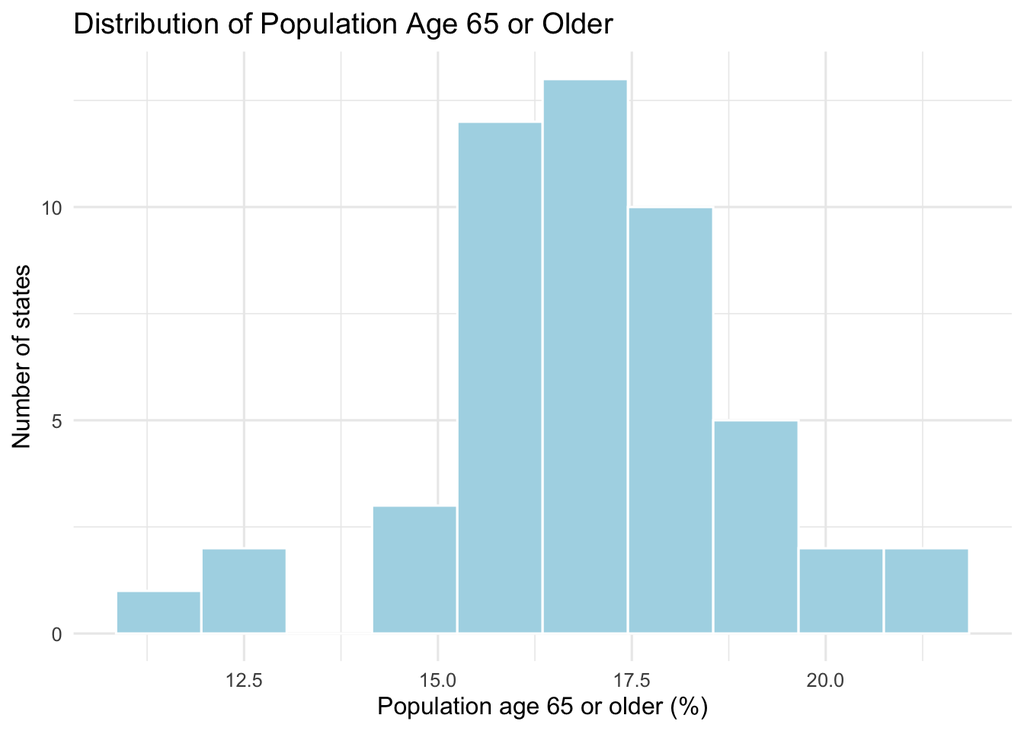

```r
ggplot(state_summary, aes(x = age65_pct)) +
  geom_histogram(
    bins = 10,
    fill = "lightblue",
    color = "white"
  ) +
  labs(
    title = "Distribution of Population Age 65 or Older",
    x = "Population age 65 or older (%)",
    y = "Number of states"
  ) +
  theme_minimal(base_size = 12)
```

The majority percentage of resident population that are age 65 or older is concentrated between 15-19% and a smaller number of states had substantially higher (20% or more) or lower (12.5% or lower) percentages.

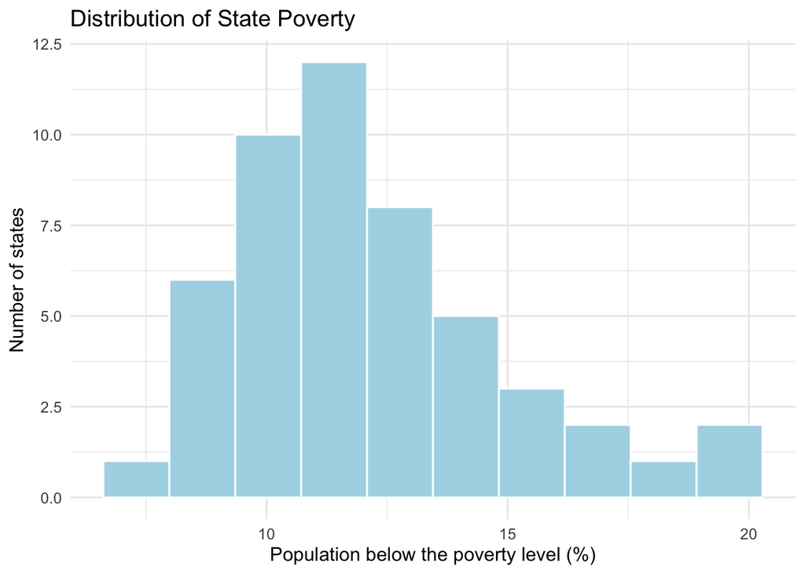

```r
ggplot(state_summary, aes(x = poverty_pct)) +
  geom_histogram(
    bins = 10,
    fill = "lightblue",
    color = "white"
  ) +
  labs(
    title = "Distribution of State Poverty",
    x = "Population below the poverty level (%)",
    y = "Number of states"
  ) +
  theme_minimal(base_size = 12)
```

State poverty percentages were slightly right-skewed and most states were concentrated between 9-15% and a few states were reaching 20%.

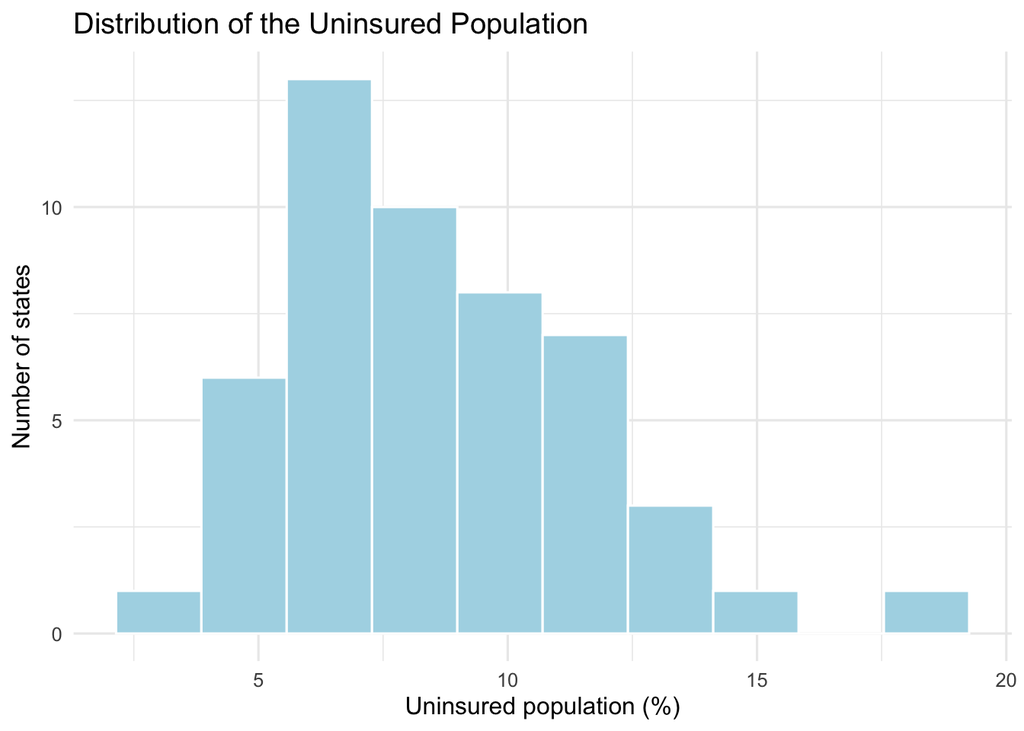

```r
ggplot(state_summary, aes(x = uninsured_pct)) +
  geom_histogram(
    bins = 10,
    fill = "lightblue",
    color = "white"
  ) +
  labs(
    title = "Distribution of the Uninsured Population",
    x = "Uninsured population (%)",
    y = "Number of states"
  ) +
  theme_minimal(base_size = 12)
```

The percentage uninsured was slightly right-skewed, and most states were between 5-16% with the exception of a few states nearing 20%.

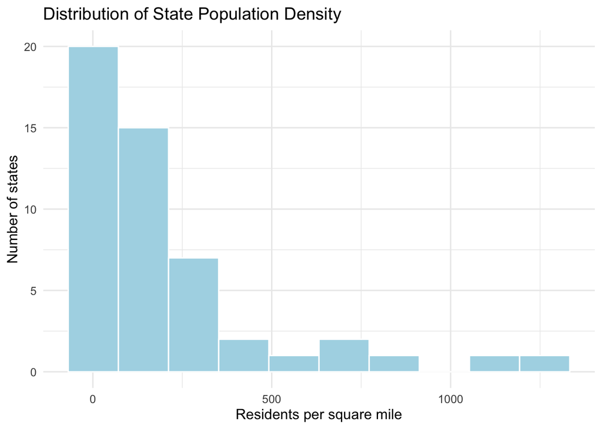

```r
ggplot(state_summary, aes(x = population_density)) +
  geom_histogram(
    bins = 10,
    fill = "lightblue",
    color = "white"
  ) +
  labs(
    title = "Distribution of State Population Density",
    x = "Residents per square mile",
    y = "Number of states"
  ) +
  theme_minimal(base_size = 12)
```

State population density was strongly right-skewed and most states had fewer than 300 residents per square mile. A small number did go over the 1,000 residents per square mile.

## Visualizations of hospital-related outcome distributions

The following distributions describe peak hospitalization and occupancy during the full September-March study period. The later hospital-capacity comparisons in Preliminary Results use separate October-March peak occupancy outcomes so that September can serve as the early reference period.

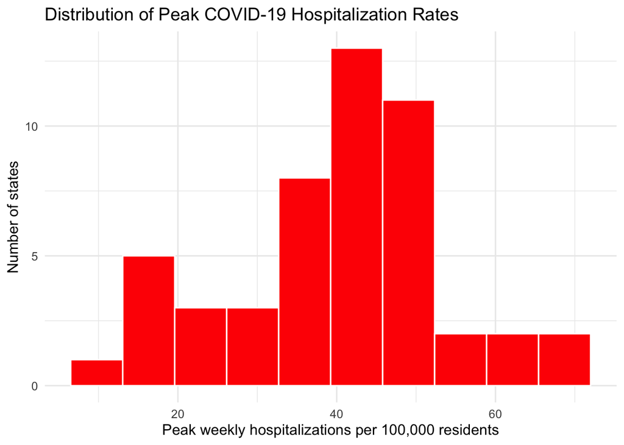

```r
ggplot(state_summary, aes(x = peak_hosp_rate)) +
  geom_histogram(
    bins = 10,
    fill = "red",
    color = "white"
  ) +
  labs(
    title = "Distribution of Peak COVID-19 Hospitalization Rates",
    x = "Peak weekly hospitalizations per 100,000 residents",
    y = "Number of states"
  ) +
  theme_minimal(base_size = 12)
```

The peak COVID-19 hospitalization rates did vary across states. Most states had peak rates between 35-55 hospitalizations per 100,000 residents.

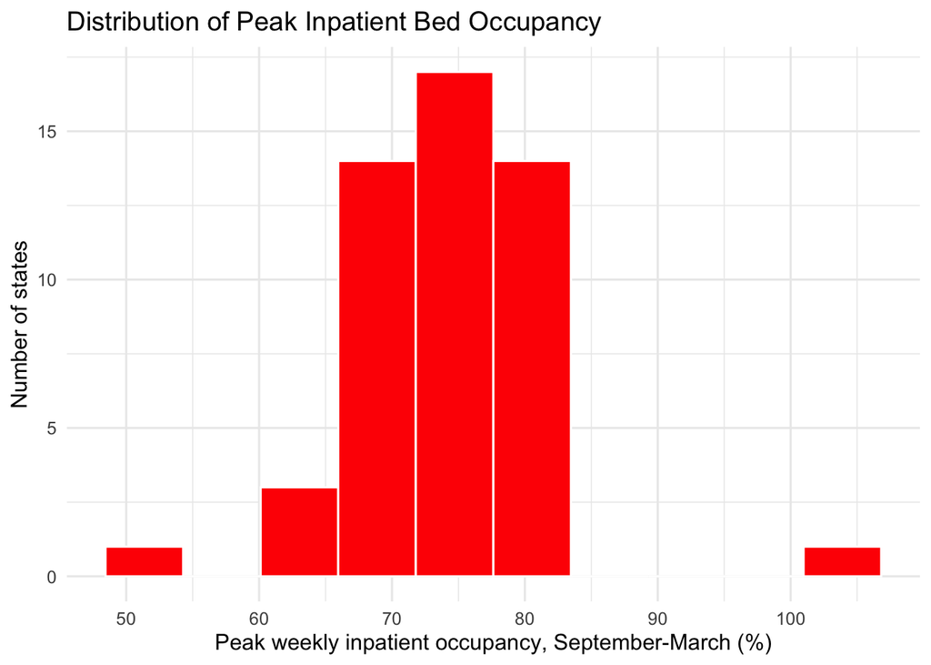

```r
ggplot(state_summary, aes(x = peak_inpatient_occupancy_pct)) +
  geom_histogram(
    bins = 10,
    fill = "red",
    color = "white"
  ) +
  labs(
    title = "Distribution of Peak Inpatient Bed Occupancy",
    x = "Peak weekly inpatient occupancy, September-March (%)",
    y = "Number of states"
  ) +
  theme_minimal(base_size = 12)
```

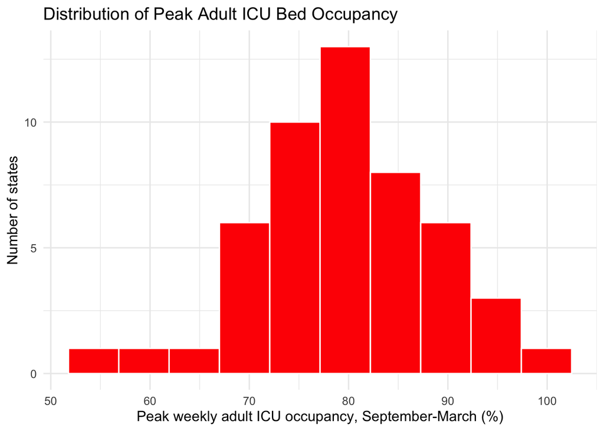

```r
ggplot(state_summary, aes(x = peak_icu_occupancy_pct)) +
  geom_histogram(
    bins = 10,
    fill = "red",
    color = "white"
  ) +
  labs(
    title = "Distribution of Peak Adult ICU Bed Occupancy",
    x = "Peak weekly adult ICU occupancy, September-March (%)",
    y = "Number of states"
  ) +
  theme_minimal(base_size = 12)
```

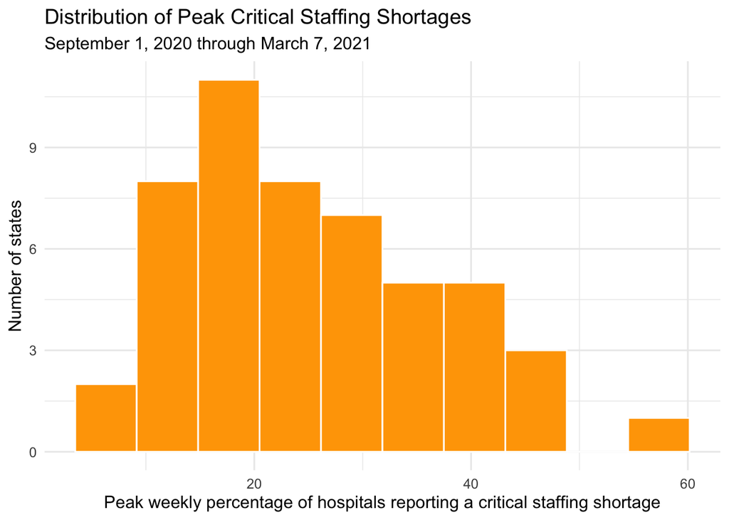

```r
ggplot(
  state_summary,
  aes(x = peak_staffing_shortage_pct)
) +
  geom_histogram(
    bins = 10,
    fill = "orange",
    color = "white"
  ) +
  labs(
    title = "Distribution of Peak Critical Staffing Shortages",
    subtitle = "September 1, 2020 through March 7, 2021",
    x = "Peak weekly percentage of hospitals reporting a critical staffing shortage",
    y = "Number of states"
  ) +
  theme_minimal(base_size = 12)
```

The peak critical staffing shortage was right-skewed slightly with most states falling in between 15% to 45% and only very few states near 60%.

## Log transforming population density

Population density was log transformed because its original distribution was strongly right-skewed. The transformation reduced the influence of a small number of extreme values.

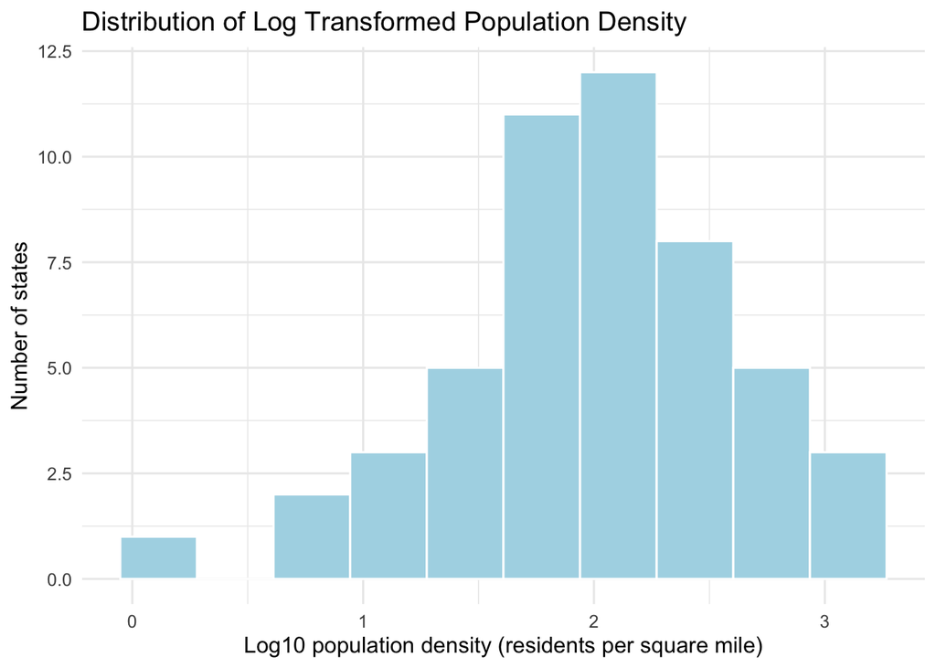

```r
ggplot(
  state_summary,
  aes(x = log_population_density)
) +
  geom_histogram(
    bins = 10,
    fill = "lightblue",
    color = "white"
  ) +
  labs(
    title = "Distribution of Log Transformed Population Density",
    x = "Log10 population density (residents per square mile)",
    y = "Number of states"
  ) +
  theme_minimal(base_size = 12)
```

## Missingness and reporting coverage

As I mentioned earlier, HHS explicitly notes that it does not statistically adjust for hospital nonresponse. Missingness is part of the EDA checklist and was examined for the primary outcome of COVID-19 hospitalization, hospital measures of capacity, staffing shortage measures, and state demographic characteristics.

```r
missingness <- tibble(
  Variable = c(
    "Current COVID-19 hospitalizations",
    "Hospitalization rate",
    "Staffed inpatient beds per 100,000",
    "Inpatient occupancy",
    "Staffed adult ICU beds per 100,000",
    "Adult ICU occupancy",
    "COVID-19 inpatient share",
    "Critical staffing shortage",
    "Population age 65 or older",
    "Poverty",
    "Uninsured",
    "Population density"
  ),

  Number_missing = c(
    sum(is.na(analysis_daily$hospitalized_currently)),
    sum(is.na(analysis_daily$hosp_rate)),
    sum(is.na(analysis_daily$beds_per_100k)),
    sum(is.na(analysis_daily$inpatient_occupancy_pct)),
    sum(is.na(analysis_daily$icu_beds_per_100k)),
    sum(is.na(analysis_daily$icu_occupancy_pct)),
    sum(is.na(analysis_daily$confirmed_adult_covid_share_pct)),
    sum(is.na(analysis_daily$staffing_shortage_pct)),
    sum(is.na(analysis_daily$age65_pct)),
    sum(is.na(analysis_daily$poverty_pct)),
    sum(is.na(analysis_daily$uninsured_pct)),
    sum(is.na(analysis_daily$population_density))
  ),

  Percent_missing = c(
    mean(is.na(analysis_daily$hospitalized_currently)) * 100,
    mean(is.na(analysis_daily$hosp_rate)) * 100,
    mean(is.na(analysis_daily$beds_per_100k)) * 100,
    mean(is.na(analysis_daily$inpatient_occupancy_pct)) * 100,
    mean(is.na(analysis_daily$icu_beds_per_100k)) * 100,
    mean(is.na(analysis_daily$icu_occupancy_pct)) * 100,
    mean(is.na(analysis_daily$confirmed_adult_covid_share_pct)) * 100,
    mean(is.na(analysis_daily$staffing_shortage_pct)) * 100,
    mean(is.na(analysis_daily$age65_pct)) * 100,
    mean(is.na(analysis_daily$poverty_pct)) * 100,
    mean(is.na(analysis_daily$uninsured_pct)) * 100,
    mean(is.na(analysis_daily$population_density)) * 100
  )
) |>
  mutate(
    Percent_missing = round(Percent_missing, 2)
  )

kable(
  missingness,
  caption = "Missingness of variables used in the analysis",
  col.names = c(
    "Variable",
    "Number missing",
    "Percent missing"
  )
)
```

Missingness of variables used in the analysis

| Variable | Number missing | Percent missing |
| --- | --- | --- |
| Current COVID-19 hospitalizations | 2 | 0.02 |
| Hospitalization rate | 2 | 0.02 |
| Staffed inpatient beds per 100,000 | 0 | 0.00 |
| Inpatient occupancy | 0 | 0.00 |
| Staffed adult ICU beds per 100,000 | 0 | 0.00 |
| Adult ICU occupancy | 1 | 0.01 |
| COVID-19 inpatient share | 0 | 0.00 |
| Critical staffing shortage | 0 | 0.00 |
| Population age 65 or older | 0 | 0.00 |
| Poverty | 0 | 0.00 |
| Uninsured | 0 | 0.00 |
| Population density | 0 | 0.00 |

Current COVID-19 hospitalizations and (as a result) hospitalization rate were missing for 2 of the 9,400 observations, almost 0.02%.. Adult ICU occupancy was missing for one observation but it is Iowa’s implausible value on September 3, 2020 that I recoded as missing. All remaining variables contained no missing values.

## State hospitalization peaks visualizations

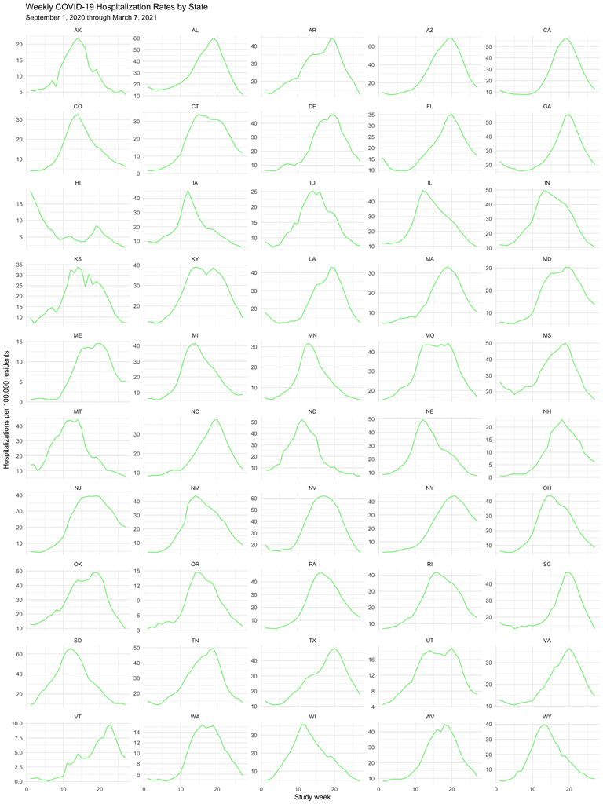

```r
ggplot(
  analysis_weekly,
  aes(
    x =study_week,
    y = hosp_rate
  )
) +
  geom_line(
    color = "lightgreen",
    linewidth = 0.6,
    na.rm = TRUE
  ) +
  facet_wrap(
    ~ state,
    ncol = 5,
    scales = "free_y"
  ) +
  labs(
    title = "Weekly COVID-19 Hospitalization Rates by State",
    subtitle = "September 1, 2020 through March 7, 2021",
    x = "Study week",
    y = "Hospitalizations per 100,000 residents"
  ) +
  theme_minimal(base_size = 10)
```

Based on the trajectories, most states did experience increased hospitalization rates during the fall to winter surge, but some states did peak earlier than others and other states did reach their highest burden later on in the winter. States either experienced a sharp peak or longer period of elevated hospitalizations,and the surge throughout the US consisted of distinct patterns. Note that the different figures used different y-axis ranges, it is most useful to understand the figure shapes rather than magnitude of hospitalization rates.

# Preliminary Results

## Peak hospitalization burden

```r
top_states <- state_summary |>
  arrange(desc(peak_hosp_rate)) |>
  select(
    State = state,
    `Peak week` = peak_hosp_week,
    `Peak hospitalizations per 100,000` = peak_hosp_rate,
    `Peak inpatient occupancy (%)` = peak_inpatient_occupancy_pct,
    `Peak ICU occupancy (%)` = peak_icu_occupancy_pct
  ) |>
  slice_head(n = 10)

kable(
  top_states,
  digits = 1,
  caption = "Ten states with the highest peak weekly hospitalization rates"
)
```

Ten states with the highest peak weekly hospitalization rates

| State | Peak week | Peak hospitalizations per 100,000 | Peak inpatient occupancy (%) | Peak ICU occupancy (%) |
| --- | --- | --- | --- | --- |
| AZ | 19 | 68.7 | 78.2 | 77.3 |
| SD | 12 | 65.5 | 67.6 | 83.4 |
| NV | 17 | 61.9 | 81.1 | 88.4 |
| AL | 19 | 59.9 | 78.5 | 95.1 |
| CA | 19 | 57.4 | 81.7 | 89.7 |
| GA | 20 | 55.7 | 83.2 | 93.6 |
| ND | 11 | 52.1 | 77.6 | 91.8 |
| MS | 19 | 49.8 | 66.8 | 93.2 |
| TN | 19 | 49.5 | 68.8 | 76.7 |
| IN | 13 | 49.4 | 69.0 | 78.7 |

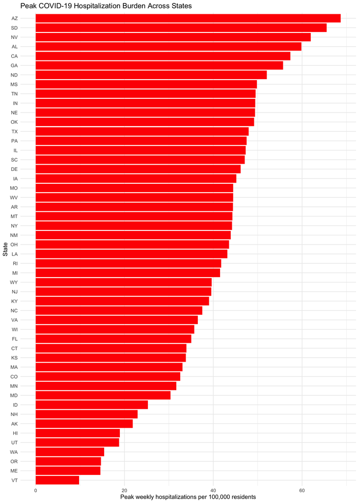

```r
ggplot(
  state_summary,
  aes(
    x = reorder(state, peak_hosp_rate),
    y = peak_hosp_rate
  )
) +
  geom_col(
    fill = "red"
  ) +
  coord_flip() +
  labs(
    title = "Peak COVID-19 Hospitalization Burden Across States",
    x = "State",
    y = "Peak weekly hospitalizations per 100,000 residents"
  ) +
  theme_minimal(base_size = 12)
```

## Map distribution

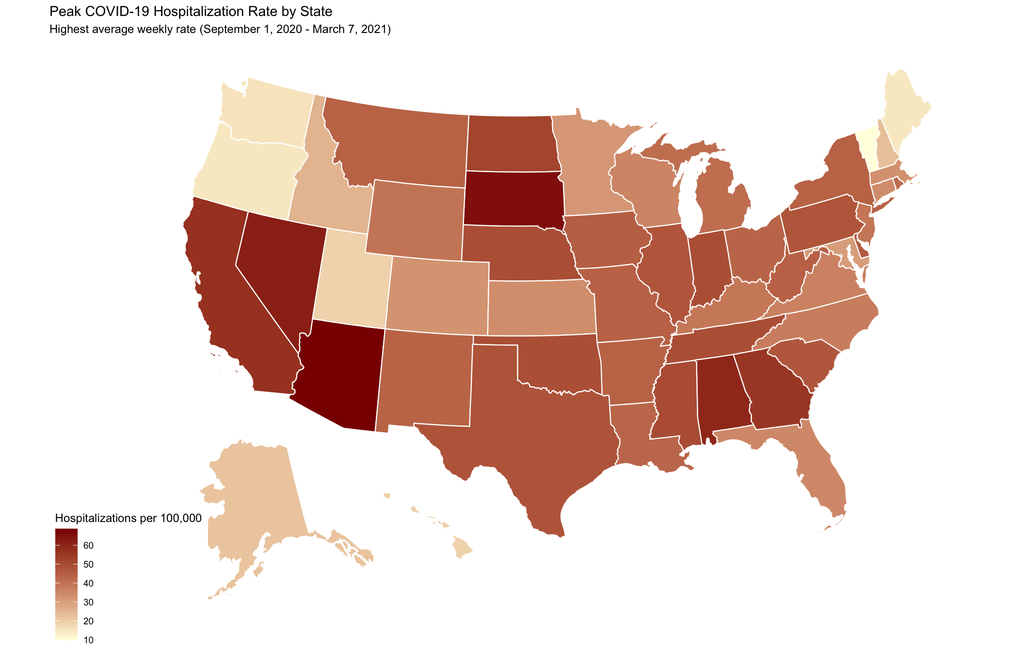

```r
library(usmap)
plot_usmap(
  data = state_summary,
  values = "peak_hosp_rate",
  color = "white"
) +
  scale_fill_gradient(
    low = "lightyellow",
    high = "darkred"
  ) +
  labs(
    title = "Peak COVID-19 Hospitalization Rate by State",
    subtitle = "Highest average weekly rate (September 1, 2020 - March 7, 2021)",
    fill = "Hospitalizations per 100,000"
  )
```

Peak weekly hospitalization burden did substantially vary across the 50 states, ranging from almost 10 to approximately 70 hospitalizations per 100,000 residents. Arizona had the highest peak rate, followed by South Dakota, Nevada, Alabama, and California, while Vermont, Maine, Oregon, Washington, and Utah were the five states that had the lowest rate. Peak weekly hospitalization rate signifies each state’s highest weekly average number of hospitalized COVID-19 patients (maximum hospitalization burden) per 100,000 residents during the fall and winter surge of 2020-2021.

## Demographic characteristics and hospitalization burden

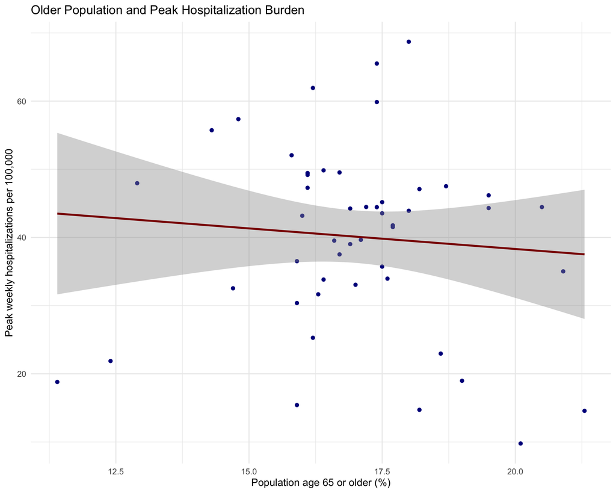

```r
ggplot(
  state_summary,
  aes(
    x = age65_pct,
    y = peak_hosp_rate
  )
) +
  geom_point(color = "darkblue") +
  geom_smooth(
    method = "lm",
    color = "darkred"
  ) +
  labs(
    title = "Older Population and Peak Hospitalization Burden",
    x = "Population age 65 or older (%)",
    y = "Peak weekly hospitalizations per 100,000"
  ) +
  theme_minimal(base_size = 12)
```

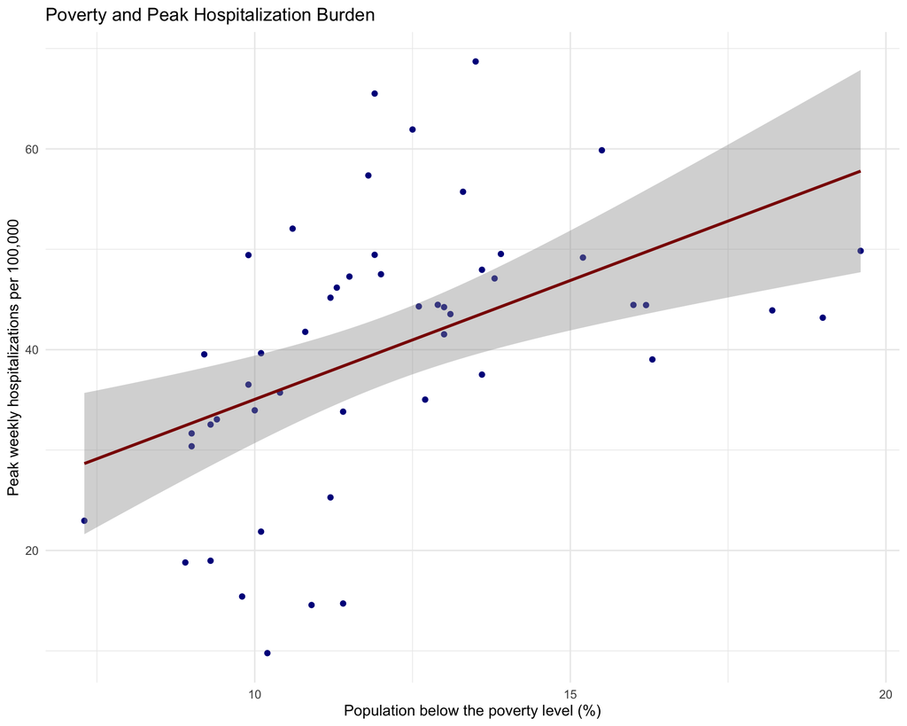

```r
ggplot(
  state_summary,
  aes(
    x = poverty_pct,
    y = peak_hosp_rate
  )
) +
  geom_point(color = "darkblue") +
  geom_smooth(
    method = "lm",
    color = "darkred"
  ) +
  labs(
    title = "Poverty and Peak Hospitalization Burden",
    x = "Population below the poverty level (%)",
    y = "Peak weekly hospitalizations per 100,000"
  ) +
  theme_minimal(base_size = 12)
```

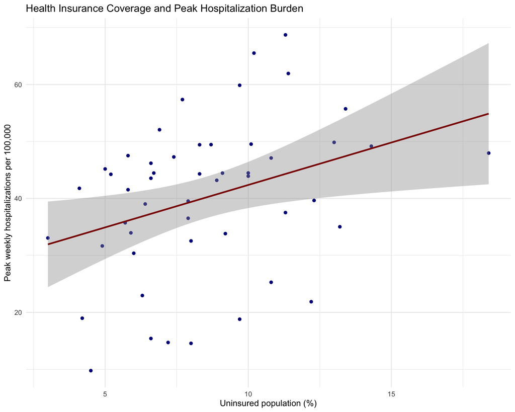

```r
ggplot(
  state_summary,
  aes(
    x = uninsured_pct,
    y = peak_hosp_rate
  )
) +
  geom_point(color = "darkblue") +
  geom_smooth(
    method = "lm",
    color = "darkred"
  ) +
  labs(
    title = "Health Insurance Coverage and Peak Hospitalization Burden",
    x = "Uninsured population (%)",
    y = "Peak weekly hospitalizations per 100,000"
  ) +
  theme_minimal(base_size = 12)
```

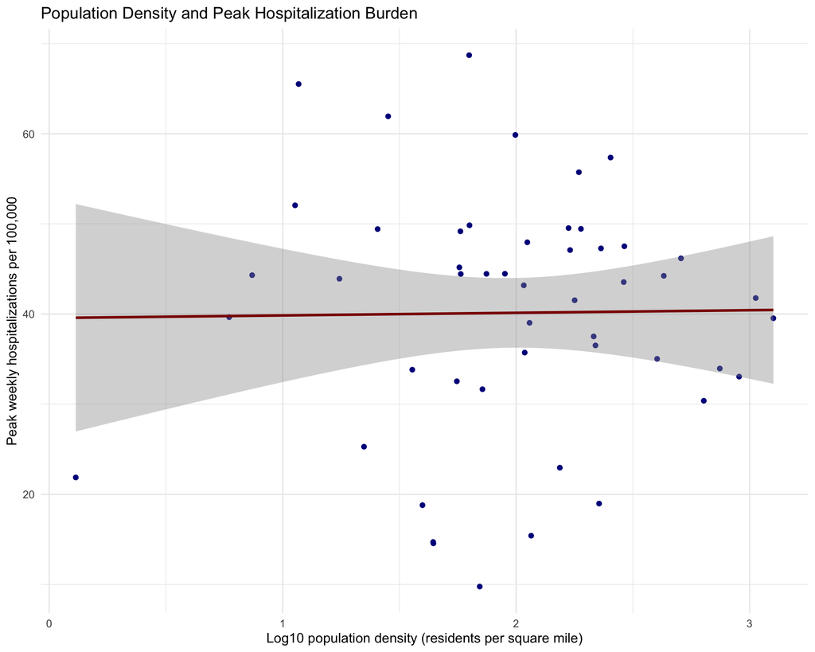

```r
ggplot(
  state_summary,
  aes(
    x = log_population_density,
    y = peak_hosp_rate
  )
) +
  geom_point(color = "darkblue") +
  geom_smooth(
    method = "lm",
    color = "darkred"
  ) +
  labs(
    title = "Population Density and Peak Hospitalization Burden",
    x = "Log10 population density (residents per square mile)",
    y = "Peak weekly hospitalizations per 100,000"
  ) +
  theme_minimal(base_size = 12)
```

For older population and hospitalization burden, the fitted line has a slight negative slope, which suggests that states with higher percentage of older residents did not necessarily experience higher peak hospitalizations. The points are scattered widely with no and the confidence interval band is wide indicating a weaker relationship.

For poverty and hospitalization burden, there is a clear positive relationship and states with higher percentages of population that fall below poverty level generally had higher peak hospitalization rates. There is still a strong variation among the states with similar poverty level rates. The confidence interval band is relatively narrow for most of the middle percentages but is wider at higher poverty percentages with fewer states represented.

For uninsured population and hospitalization burden, there is a positive association between states with higher uninsured population percentages generally have higher peak hospitalization rates. The confidence interval band is relatively wide, especially for higher uninsured percentages, indicating there is a lot of uncertainty and fewer states with higher percentages.

For population density (observed in a log base scale) and peak hospitalization rates, the fitted line is nearly horizontal indicating that there is little evidence of an association between these two variables.

These findings of the relationships are exploratory and should not be interpreted as causal.

## Hospital Capacity and Hospital Strain at September 2020 Starting Conditions

September 2020 hospital conditions were compared to peak weekly hospital occupancy from October 2020 through March 7, 2021 for all 50 states. Measures of resource availability, occupancy, and staffing shortages during September are visualized in relation to later hospital strain without including September observations in the outcome period. The scatterplots describe patterns across states and were not intended to establish any causal relationships.

### Inpatient bed supply

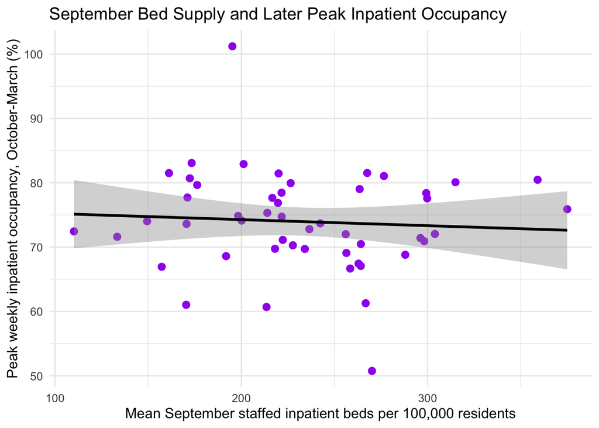

```r
#| fig-width: 8
#| fig-height: 6

ggplot(
  state_analysis,
  aes(
    x = baseline_beds_per_100k,
    y = later_peak_inpatient_occupancy_pct
  )
) +
  geom_point(
    color = "purple",
    size = 2.5
  ) +
  geom_smooth(
    method = "lm",
    se = TRUE,
    color = "black"
  ) +
  labs(
    title = "September Bed Supply and Later Peak Inpatient Occupancy",
    x = "Mean September staffed inpatient beds per 100,000 residents",
    y = "Peak weekly inpatient occupancy, October-March (%)"
  ) +
  theme_minimal(base_size = 12)
```

The scatterplot between mean September staffed inpatient beds per 100,000 residents and peak weekly inpatient occupancy shows a very weak negative association. The nearly flat line and wide scatter of points indicate that states with more bed availability in September did not consistently experience lower peak weekly inpatient occupancy in the later motnhs. Bed supply at beginning of the study period alone may not explain differences in later strain in hospitals across states.

### ICU Bed Supply

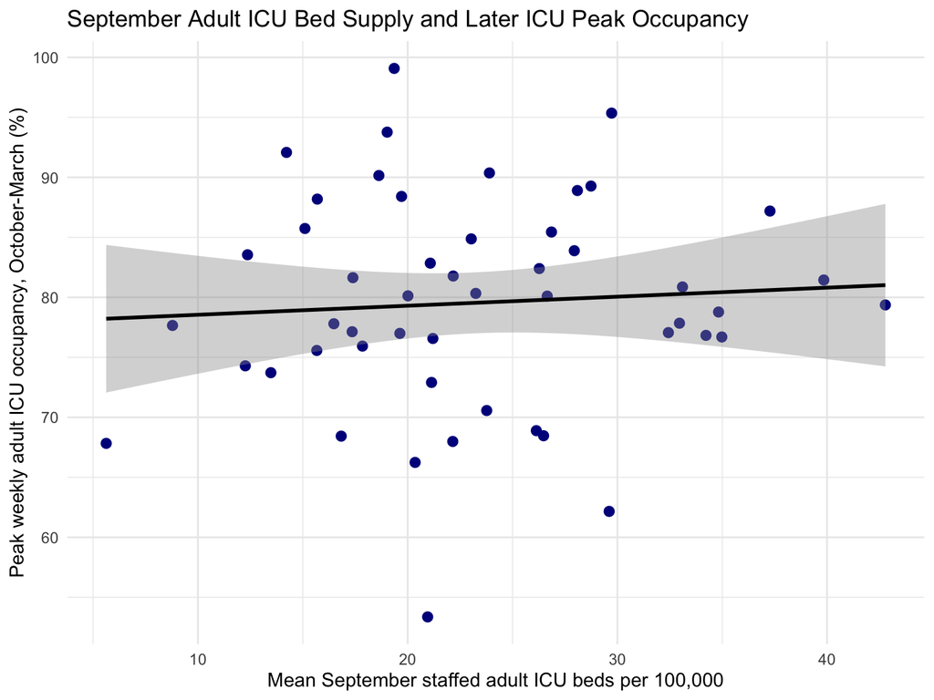

```r
ggplot(
  state_analysis,
  aes(
    x = baseline_icu_beds_per_100k,
    y = later_peak_icu_occupancy_pct
  )
) +
  geom_point(
    color = "darkblue",
    size = 2.5
  ) +
  geom_smooth(
    method = "lm",
    se = TRUE,
    color = "black"
  ) +
  labs(
    title = "September Adult ICU Bed Supply and Later ICU Peak Occupancy",
    x = "Mean September staffed adult ICU beds per 100,000",
    y = "Peak weekly adult ICU occupancy, October-March (%)"
  ) +
  theme_minimal(base_size = 12)
```

There is a very weak positive association between mean September staffed adult ICU beds per 100,000 residents and peak weekly adult ICU occupancy during the surge in later months. States with similar ICU bed availability also experienced widely different peak occupancy percents, and the nearly flat trend line with a wide confidence band suggests that baseline bed supply alone did not clearly explain later ICU strain.

### ICU Occupancy

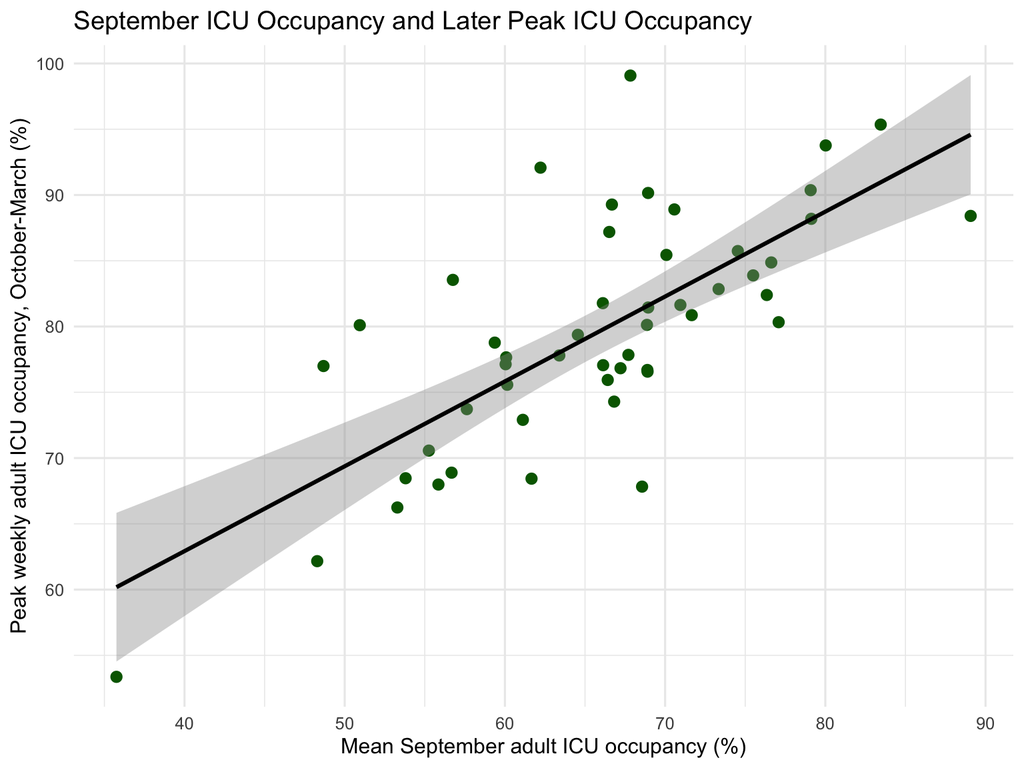

```r
ggplot(
  state_analysis,
  aes(
    x = baseline_icu_occupancy_pct,
    y = later_peak_icu_occupancy_pct
  )
) +
  geom_point(
    color = "darkgreen",
    size = 2.5
  ) +
  geom_smooth(
    method = "lm",
    se = TRUE,
    color = "black"
  ) +
  labs(
    title = "September ICU Occupancy and Later Peak ICU Occupancy",
    x = "Mean September adult ICU occupancy (%)",
    y = "Peak weekly adult ICU occupancy, October-March (%)"
  ) +
  theme_minimal(base_size = 12)
```

States with higher mean adult ICU occupancy in September 2020 generally also experienced higher peak weekly adult ICU occupancy during October through March. This positive association indicates that states that started with greater use of their adult ICU capacity during September also seemed to reach greater peak ICU strain later in time. Several observations were far from the fitted line, showing that September ICU occupancy did not fully explain later differences.

### Staffing shortages

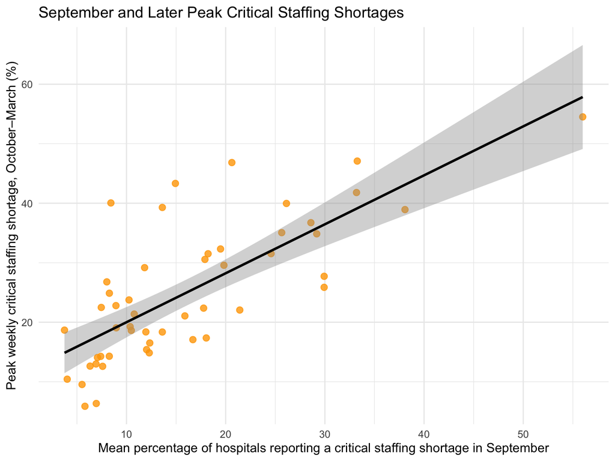

```r
ggplot(
  state_analysis,
  aes(
    x = baseline_staffing_shortage_pct,
    y = later_peak_staffing_shortage_pct)
) +
  geom_point(color = "orange", alpha = 0.8, size = 2.5) +
  geom_smooth(method = "lm", se = TRUE, color = "black") +
  labs(
  title = "September and Later Peak Critical Staffing Shortages",
  x = "Mean percentage of hospitals reporting a critical staffing shortage in September",
  y = "Peak weekly critical staffing shortage, October–March (%)"
) +
  theme_minimal(base_size = 12)
```

Mean September critical staffing shortage percents showed a positive association with peak weekly staffing shortages from October through March. States that reported higher peak staffing shortage in September also experienced higher percents levels during the later period, and the wide confidence band indicates great amount of uncertainty. While September staffing shortages had variation among states with similar values and the confidence interval awas wide at higher percentages, the overall pattern suggests that early staffing difficulties often continued or became more severe later on.

# Conclusion

This exploratory analysis examined whether state demographic and hospital characteristics were associated with peak COVID-19 hospitalization burden during the fall and winter of the 2020-2021 surge. Considerable variation in hospitalization rates and hospital strain was observed across 50 states. Poverty showed the clearest positive relationship with peak hospitalizations per 100,000 residents. The uninsured percentage showed a weaker positive pattern, the percentage of older residents showed a weak negative pattern, and log-transformed population density showed little to no relationship with peak hospitalization burden. These findings suggest that **state differences in hospitalization burden could not be explained by population density, health-insurance coverage, or older age composition alone.**

These results should be interpreted as exploratory associations by state-level rather than causal relationships. September hospital conditions were compared with peak occupancy from October 1, 2020 through March 7, 2021, so September observations were not included in the later outcome period. Separating the early reference and later outcome periods improved the order of the analysis, but it does not establish that September conditions caused the later strain. The analysis also used aggregated state data, so its findings cannot be applied directly to individual hospitals or patients. Reporting completeness and definitions may have differed across states, and the occupancy values exceeding 100% could reflect beyond staffed capacity reporting or reporting inconsistencies. The 2019 ACS characteristics were treated as fixed pre-pandemic measures and may not capture changes during the study period. Despite limitations, combining demographic, population, hospitalization, and hospital-capacity data provided a better picture of differences in COVID-19 hospital burden and strain across the states. **State-level COVID-19 hospitalization burden and hospital strain were likely shaped by multiple factors.**

# AI Use Statement

I used ChatGPT to support the organization, coding, and revision of this midterm. I used it to troubleshoot R errors, clarify any bugging fixes, and consider the order of data preparation and EDA steps. It helped me understand why an implausible value should be addressed before recalculating the weekly and state-level summaries or how to reorder my code to follow my line of thinking. I also used it to consider to examine the associations between hospital capacity and peak hospital strain, where I did keep wondering what outcome measures to compare and why. I also used it to improve figure labels and visualizations that were not sized correctly. I reviewed, tested, and considered all AI-generated suggestions for accuracy and consistency with the course material. The final analytical decisions, interpretations, and conclusions reflect my own understanding of the data. AI was only used to understand possible analytical approaches or reorganize the data structure, but all final decisions were made by me and reflect my own work for the project objectives.